# Kapittel 10 og 11

# Kapittel 10 og 11: Grunnskole, videregående utdanning og høyere utdanning

## 10.1 Introduksjon

- Kapittel 10, om **grunnskoleutdanning og vg** , og Kapittel 11, om **høyere utdanning**, må ses i sammenheng
  - ved hjelp av økonomisk teori når man forskjellige konklusjoner om statens rolle
  - NB! Equity-begrepet er vanskelig å oversette til norsk
    - equality: kan oversettes med likhet
    - equity: like muligheter eller lik tilgang

## Målet med utdanning

- samfunnets velferd maksimeres gjennom å øke effektivitet og sosial rettferdighet

### Grunnskole og vg

- hovedmålet: å oppnå bedre utdanningsresultater
  - kilder til bedre utdanningsresultater:
    - inntekt / formue
    - individuelle valg
    - foreldre
    - medelever/-studenter
    - innfødte evner
- delmål: å overføre
  - kunnskaper og ferdigheter, *og*
  - holdninger og verdier
  - felles kunnskapsbase, felles verdier –> sosial kohesjon

### Spefisikke mål for høyere utdanning

- å fremme
  - intellektuell frihet og mangfold, mindre vekt på sosial kohesjon
  - jakten på kunnskap for sin egen skyld
- idéfrihet

## Instrumentelle mål: effektivitet og rettferdighet

- **Øker utdanning samfunnets effektivitet?**
  - måle kostnadene ved utdanning: gjennomførbart
    - (Gjennomsnittlige årlige utdanningskostnader i Danmark pr. student i 2019 i danske kroner)[https://cepos.dk/media/6202/notat_er-hoejere-uddannelse-oversubsidieret.pdf] .
      - direkte kostnader 59.927
      - studiestøtte (etter skatt) 64.418
      - alternativinntekt (etter skatt) 235.577
      - øvrige kostnader 10.000
      - i alt 369.922
  - måle nytten av utdanning: vanskelig å kvantifisere
    - nytteeffektene med utdanning er veldig brede
      - **konsumnytte**
        - man kan nyte selve utdanningsprosessen
      - **investeringsnytte**
        - høyere lønn
        - større arbeidsglede
        - større nytelse av fritid
      - positive eksternaliteter (mer om dette senere)
  - det er vanskelig å etablere sammenheng mellom innsatsfaktorer og resultater
    - mulig å måle innsatsfaktorers kvantitet, men ikke kvalitet
    - umulig å måle mange andre faktorer (innfødte evner, kvalitet av undervisning, kvalitet på foreldrene osv.)
  - årsakssammenheng kan ikke fastslås
    - screeninghypotesen stiller spørsmål ved årsakssammenhengen mellom høyere utdanning og økt individuell produktivitet
      - er en person produktiv fordi hen har innfødte evner, eller fordi hen har blitt godt utdannet?
  - en stor utfordring å etablere de kausale koblingene mellom utdanning og vekst:
    - vekst i produksjonen avhenger av
      - økningen i mengde og kvalitet av kapitalbeholdningen
      - økningen i mengde og kvalitet av arbeidsstyrken
      - ikke-økonomiske faktorer
    - **utdanning påvirker bare kvaliteten på arbeidsstyrken**
      - problemet er å skille den kvantitative effekten av denne variabelen gitt påvirkningen av alle de andre
      - dette sagt, mange studier finner at utdanning er en betydelig driver av vekst
        - “å bringe alle land opp til gjennomsnittlig prestasjon av Finland, OECDs best presterende utdanningssystem …, ville resultere i gevinster i størrelsesorden USD 260 billioner” (OECDD 2010b: 6)
- **Øker utdanning samfunnets rettferdighet?**
  - rettferdighet anses å innebære at barn (studenter) A og B skal ha **like** **muligheter** til å skaffe seg en utdanning av lik kvalitet
  - horisontal likhet: **like muligheter** innebærer ikke nødvendigvis **likhet i utfall** av minst tre grunner: - A kan være heldigere enn B - A og B kan ha forskjellig smak - A kan være mer “dyktig” enn B (der slike forskjeller ikke er relatert til utdanningsmessige og sosiale forhold tidligere i livet)
  - vertikal likhet: skatter
    - er utdanning finansiert med progressiv beskatning?
      - grunnutdanning leveres uten kostnad for elever og finansieres gjennom skatter
        - alle konsumerer samme mengde
        - denne utdanningen er omfordelende (**progressiv**): rike foreldre betaler mer skatt enn fattige foreldre
      - i motsetning til obligatorisk skolegang, kan folk velge om de vil søke universitet eller ikke
        - studenter på universitet kommer uforholdsmessig ofte fra mer velstående bakgrunner
          - skattefinansieringen av høyere utdanning tenderer til å være **regressiv**
  - utjevner “gratis” utdanning alle forskjellene når det gjelder tilgang?
  - livsløps- og intergenerasjonelle effekter
    - betydningen av utviklingen i tidlig barndom
    - utdanningsmessig ulikhet påvirker ikke bare den enkelte, men har også intergenerasjonelle effekter

## 10.3.1 Teoretiske argumenter for offentlig inngrep 1: effektivitet: markedssvikt

## Ufullkommen informasjon

**Grunnskole og vg**

- i et privat markedsssystem:
  - barn er ikke godt informert
  - foreldrene bestemmer
    - bare delvis informert f.eks. om kvalitet

**Høyere utdanning**

- i et privat markedsssystem:
  - studentene er velinformerte
    - det er mer sannsynlig at studentene gjør bedre valg for seg selv enn staten hadde gjort
    - studenter er bedre enn staten til å gjøre valg som samsvarer med deres egne og samfunnets behov etter hvert som elevene blir eldre (konsumentsuverenitet)
    - **mindre informasjonsproblemer i høyere utdanning**
      - mer konsumentsuverenitet i høyere utdanning enn i grunnskoleutdanning

## Irrasjonell adferd

**Grunnskole**

- i et privat markedsssystem:
  - problem med begrenset rasjonalitet (vet individer hvilke valg som maksimerer deres nytte)?
  - foreldre bestemmer
    - vet foreldre hvilke valg som maksimerer deres barns nytte?
    - foreldre vil kanskje ikke ta hensyn til barnets beste, men familiens beste (lav konsumentsuverenitet)
    - noen familier er i stand til å gjøre bedre valg for sine barn enn staten, noen er ikke det
      - er valgene knyttet til familiens sosioøkonomisk status?

**Høyere utdanning**

- **mindre problem med begrenset rasjonalitet**
  - studentene antas å vite i større grad hvilke valg som maksimerer deres nytte

## Implikasjoner av informasjonsproblemer (se video)

- Om bare privat marked skulle tilby utdanning, vil ufullkommen informasjon føre til ineffektivitet
  - problemet ville være større i grunnskole og vg enn i høyere utdanning
    - det er sannsynlig at ufullkommen informasjon vil føre til lavere forbruk av utdanning enn det optimale nivået for samfunnet, spesielt i lavere sosioøkonomiske grupper

```
# A tibble: 3 × 2
      x     y
  <dbl> <dbl>
1  4.65  3.40
2  6.28  4.79
3  7.69  6.36
```

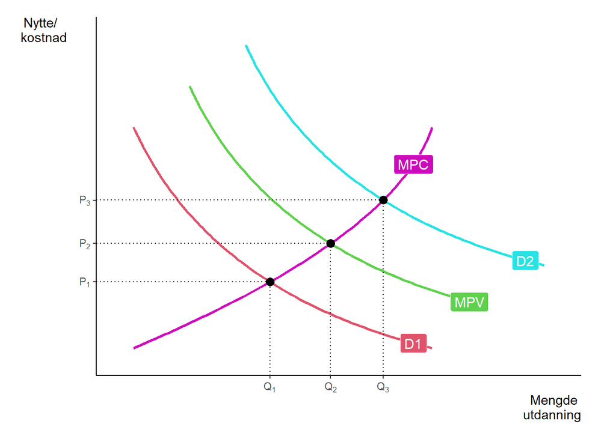

```r
library(econocharts)
library(ggplot2)

demand1 <- data.frame(Hmisc::bezier(c(1, 3, 9),
                                    c(9, 3, 1)))

demand2 <- data.frame(Hmisc::bezier(c(2.5, 4.5, 10.5),
                                    c(10.5, 4.5, 2.5)))

demand3 <- data.frame(Hmisc::bezier(c(4, 6, 12),
                                  c(12, 6, 4)))

supply1 <- data.frame(Hmisc::bezier(c(1, 8, 9),
                                    c(1, 5, 9)))

# Supply and demand curves
sdcurve(supply1, demand1, demand2 , supply1, demand3,supply1,
        names = c("MPC", "D1","MPV","MPC","D2","MPC"),
        xlab = "Mengde \n utdanning", ylab = "Nytte/ \n kostnad")
```

## Positive eksternaliteter

- **positive eksternaliteter i utdanning**
  - de positive effektene som en persons utdanning har på samfunnet som helhet, som den personen ikke blir kompensert for
    - i neoklassisk økonomisk teori vurderer individene kun de **private** fordelene og kostnadene ved å ta en beslutning, som for eksempel å investere i sin egen utdanning
    - men deres utdanning har også positive effekter på samfunnet som helhet
      - Økt innbetaling av skatt
      - Raskere økonomisk vekst - min utdanning gjør også andre mer produktive
      - Bedre respons på økonomisk endring
      - Sterkere sosial samhørighet
      - Bedre foreldre
      - Bra for demokrati
    - dette kan føre til at individene undervurderer verdien av utdanning, og dermed **investerer mindre i utdanning enn det som ville være optimalt for samfunnet som helhet**

## Positive eksternaliteter (se video)

```
# A tibble: 2 × 2
      x     y
  <dbl> <dbl>
1  4.65  3.40
2  6.28  4.79
```

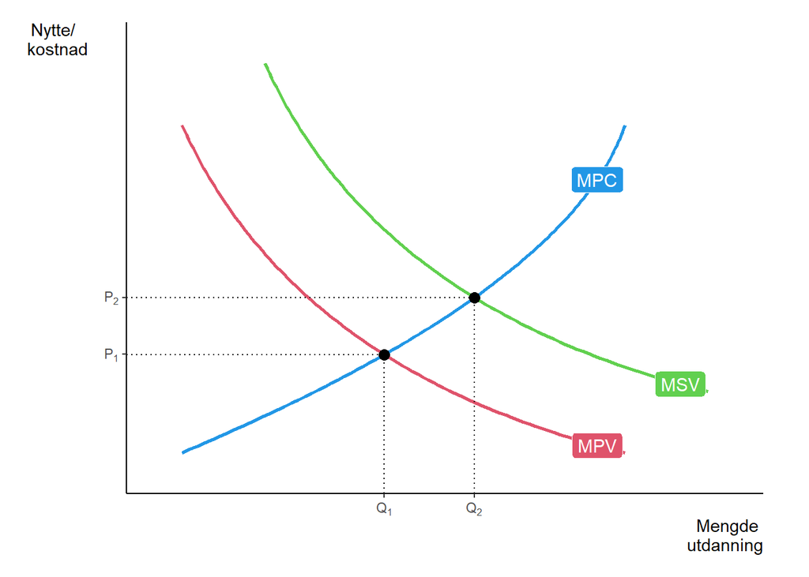

```r
library(econocharts)
library(ggplot2)

# Add custom curves
demand1 <- data.frame(Hmisc::bezier(c(1, 3, 9),
                                    c(9, 3, 1)))

demand2 <- data.frame(Hmisc::bezier(c(2.5, 4.5, 10.5),
                                    c(10.5, 4.5, 2.5)))

supply1 <- data.frame(Hmisc::bezier(c(1, 8, 9),
                                    c(1, 5, 9)))
#with bezier
supply2 <- data.frame(Hmisc::bezier(c(1, 8, 9),
                                    c(1, 5, 9) -2.55))
#without bezier, the same answer
supply2 <- data.frame(x = supply1$x, y = supply1$y - 2.55)

# Supply and demand curves - externalities
sdcurve(supply1, demand1, demand2,supply1,
        names = c("MPC", "MPV","MSV", "MPC"),
        xlab = "Mengde \n utdanning", ylab = "Nytte/ \n kostnad")
```

## Positive eksternaliteter

**Grunnskole**

- utdanning vil gi både eleven privat nytte og nytte for samfunnet
  - i et rent privat markedssystem:
    - **investerer mindre i utdanning enn det som ville være optimalt for samfunnet som helhet**

**Høyere utdanning**

- høyere utdanning gir (vanligvis) **mye mer privat nytte** enn grunnskoleutdanning
  - høyere inntekt
  - mer tilfredsstillende jobber
  - større glede av fritiden
- i et rent privat markedssystem:
  - **investerer mindre i utdanning enn det som ville være optimalt for samfunnet som helhet**

## Manglende markeder og ufullstendige kontrakter

**Manglende markeder**

- **Høyere utdanning**
- markedet for utdanningsfinansiering er imperfekt
  - studenter som ønsker å låne ikke kan tilby fysisk eller økonomisk sikkerhet
  - i et rent markedssystem vil dette føre til **underforbruk**
    - mange studenter ville ikke hatt tilgang til nødvendig finansiering for å dekke kostnadene ved høyere utdanning, inkludert levekostnader
    - ville vært en betydelig barriere for mange potensielle studenter
    - ville ført til **underinvestering i humankapital,** noe som er uheldig både for den enkelte og for samfunnet som helhet
      - særlig for lavere samfunssøkonomiske grupper
  - mangelen på sikkerhet er årsaken til det imperfekte markedet for studielån
    - når noen kjøper et hus
      - hen vet hva hen kjøper
      - det er lite sannsynlig at huset faller sammen
      - verdien av huset vil sannsynligvis gå opp
      - hvis lånetakerens inntekt faller uventet, kan han vanligvis selge huset for å betale tilbake lånet - når noen låner for en utdanning - de kan være dårlig informert om produktets natur, spesielt hvis de kommer fra en familie uten akademikere
  - når noen skal ta utdanning
    - høy risiko (eller i det minste en oppfattet høy risiko, som igjen er høyere for personer uten tidligere universitetserfaring i familien) for å ikke bli ferdig
    - selv om gjennomsnittlig privat avkastning for utdanning er positiv, er det betydelig variasjon rundt den
    - det er ingen sikkerhet for lånet
    - hvis låntakerens inntekt faller uventet, er det ingen mulighet til å selge graden for å betale tilbake lånet

## Ufullstendige kontrakter

- vanskelig å spesifisere alt i kontrakt
  - for eksempel kan en kontrakt mellom en skole og en elevs foreldre spesifisere kostnader, varighet av kurset, og andre grunnleggende vilkår, men den kan være ufullstendig med hensyn til å spesifisere kvaliteten på undervisningen som skal gis, kvalifikasjonene til lærerne osv.

## Ufullkommen konkurranse

**Grunnskole**

- i et rent markedssystem: skoler i byer ville hatt konkurranse, men en rural skole ville hatt et lokalt monopol –> vil produsere mindre enn optimalt for samfunnet

**Høyere utdanning**

- mange universiteter og høyskoler
- elevene kan bo hjemmefra
- fjernundervisning
- i et rent markedssystem: mer konkurranse i høyere utdanning enn i grunnskoleutdanning 7

## 10.3.2 Teoretiske argumenter for offentlig inngrep: rettferdighet

- horisontal likhet
  - “lik tilgang til utdanning”
    - foreldre fra lavere sosioøkonomiske grupper kan ha mindre informasjon om skolevalg
    - de kan også være mindre i stand til å bruke denne informasjonen
    - kostnader for å innhente informasjon kan også være høyere
  - det er betydelig forskjeller i tilgang til skolegang av høy kvalitet og til informasjon om fordelene med en utdanning
    - dermed er det hovedsakelig folk fra høyere samfunnslag som går på universitetet
- Én person med vanskeligstilt bakgrunn er mer sannsynlig
  - å bli dårlig informert om fordelene ved å gå på universitetet
  - å gjøre det mindre bra når det gjelder livsløps- og intergenerasjonelle effekter
  - å gå på en dårligere grunnskole

## 10.3.3 Ulike typer av **offentlige inngrep** av effektivitetsgrunner

## Informasjonsproblemer og manglende rasjonalitet

**Grunnskole**

- private konsumvalg er effektive bare hvis familier har tilstrekkelig informasjon og om de bruker denne informasjonen til barnets beste
  - **inngrep: regulering**
    - obligatorisk skolepliktig alder (for å forhindre underforbruk)
    - det offentlig er mer effektiv enn privat sektor i kvalitetskontroll:
      - læreplan
      - kvalifikasjonskrav for lærere
      - skolegodkjenninger
  - **inngrep: informasjonsformidling**

**Høyere utdanning**

- **inngrep**:
  - **informasjonsformidling**:
    - Samordna opptak, Studiebarometeret osv.
  - **regulering**
    - tilsyn og evalueringer av institusjonene og deres studieprogrammer
    - kvalifikasjonskrav
    - godkjenninger

## Positive eksternaliteter

**Grunnskole**

- offentlig subsidiering av utdanning

**Høyere utdanning**

- offentlig subdisiering av utdanning
- økonomiske subsidier til studenter
- høyere utdanning gir (vanligvis) mye mer *privat nytte* enn grunnskoleutdanning
  - det er effektivt at studenter bærer en del av kostnadene

### Positive eksternaliteter og subsidiering (se video)

```
# A tibble: 3 × 2
      x     y
  <dbl> <dbl>
1  4.65  3.40
2  6.28  4.79
3  6.28  2.23
```

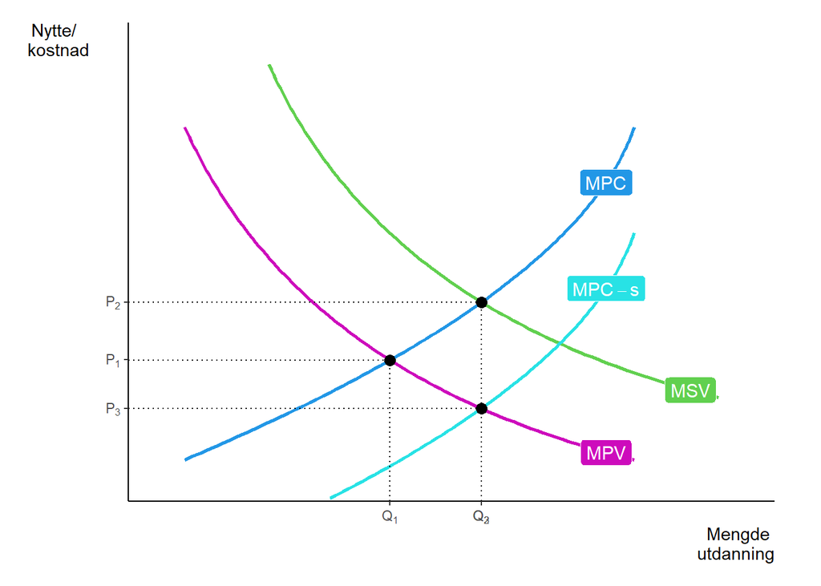

```r
library(econocharts)
library(ggplot2)
#| fig-cap: "Subsidiering av utdanning som løsning på positive eksternaliteter"
# Add custom curves
demand1 <- data.frame(Hmisc::bezier(c(1, 3, 9),
                                    c(9, 3, 1)))

demand2 <- data.frame(Hmisc::bezier(c(2.5, 4.5, 10.5),
                                    c(10.5, 4.5, 2.5)))

supply1 <- data.frame(Hmisc::bezier(c(1, 8, 9),
                                    c(1, 5, 9)))
#with bezier
supply2 <- data.frame(Hmisc::bezier(c(1, 8, 9),
                                    c(1, 5, 9) -2.55))
#without bezier, the same answer
supply2 <- data.frame(x = supply1$x, y = supply1$y - 2.55)

# Supply and demand curves -externalities and subsidies
sdcurve(supply1, demand1, demand2,supply1,supply2,demand1,
        names = c("MPC", "MPV","MSV", "MPC","MPC-s","MPV"),
        xlab = "Mengde \n utdanning", ylab = "Nytte/ \n kostnad")
```

## Ufullkomne kapitalmarkeder

**Høyere utdanning**

- Statens lånekasse for utdanning (Lånekassen)
  - tilbyr lån og stipender til studenter for å hjelpe dem med å finansiere sin høyere utdanning
    - gunstige vilkår
      - lav rente
      - ingen krav til sikkerhet
      - fleksible tilbakebetalingsbetingelser

## Ufullstendige kontrakter

- regulering av utdanningskvalitet
- minimumskrav til kvaliteten på utdanningen som skal gis av skoler og høyere utdanningsinstitusjoner
- kan inkludere krav til lærernes kvalifikasjoner, pensuminnhold, og fasiliteter som må være tilgjengelige for studentene

## 10.3.3 Ulike typer av offentlige inngrep av rettferdighetsgrunner

**Grunnskole og videregånde**

- like muligheter?
  - relaterer seg til perfekt informasjon (for å bistå rasjonelle valg)
  - disse problemene kan være større for individer i lavere sosioøkonomiske grupper
  - foreldre med liten utdanning ha mindre informasjon om skolevalg enn bedre utdannede foreldre
  - i tillegg kan de være mindre i stand til å utnytte informasjonen de faktisk får tak i
- **inngrep**
  - forbedre informasjon
  - forbedre grunnskoleutdanningen
  - gi økonomisk hjelp
  - disse inngrepene burde skje tidlig i skoleløpet

**Høyere utdanning**

- offentlig inngrep av rettferdighetsgrunner hvis ikke alle er like godt informert og ikke har en like god skoleutdanning
- mer sannsynlig at mennesker fra vanskeligstilte bakgrunner enn de fra bedre stilte bakgrunner
  - er dårlig informert om fordelene med en grad
  - gjør det mindre bra når det gjelder livssyklus- og intergenerasjonseffektene
  - går på en mindre god skole
- inngrep for å fremme tilgang til høyere utdanning av rettferdighetsgrunner i stor grad er berettiget av ulikhet tidligere i systemet
  - mye av intervensjonen bør skje under tidligere utdanning

## Offentlig produksjon, allokering og finansiering? Ja

- Disse problemene dreier seg avgjørende om svarene på to spørsmål
  - Gjør foreldre bedre eller dårligere beslutninger enn staten om barnas utdanning?
    - svaret er empirisk
  - Om familier med lavere sosioøkonomisk status gjør systematisk dårligere beslutninger, hvordan vekter vi kravene til middelklassebarn og deres foreldre om å ha valgmuligheter, i forhold til kravene til barn fra lavere sosioøkonomiske grupper, hvis interesser kan være bedre tjent av staten?
    - libertarianere:
      - hevder at offentlig inngrep forstyrrer foreldrenes frihet
    - demoratiske sosialister:
      - målet om likhet er overordnet
        - kravet fra barn fra fattigere familier prioriteres
      - offentlig allokering foretrekkes både for å sikre at barn med dårligere bakgrunn går på en god skole og for å sikre en elevsammensetning som oppmuntrer til utdanning og fremmer sosialt samhold
    - liberale
      - prøver å anerkjenne kravene til begge grupper
      - et system enten basert på offentlig allokering, som tar noe hensyn til foreldrenes preferanser, eller basert på foreldrenes valg som overvåkes nøye

## Lærdommer fra økonomisk teori

**Grunnskole og videregående**

- markedssviktene tilstrekkelig store til å gjøre **offentlig produksjon og finansiering** mer effektiv enn det private markedet hadde klart
- **regulering** kan rettferdiggjøres av ufullkommen informasjon, irrasjonell adferd, ufullstendige kontrakter, og tilstedeværelsen av eksternaliteter og lokale monopoler
- **subsidiering** kan rettferdiggjøres av positive eksternaliteter, og tilbud av lån av ufullkomne kapitalmarkeder
- spørsmålet om *offentlig produksjon* hviler i stor grad på omfanget av informasjonsproblemer fra barn og foreldre, og på om kvalitet overvåkes mer effektivt i offentlig sektor
- det bør være klart at et rent markedsystem sannsynligvis vil være **svært ineffektivt**, og også urettferdig i den grad kunnskap og tilgang til kapitalmarkeder er korrelert med sosioøkonomisk status
- et privat markedsdssystem som tilbyr grunnskole- og videregående utdanning er teoretisk usannsynlig, og eksisterer i praksis ikke i noe land

**Høyere utdanning**

- informasjonsproblemer er mindre - mindre inngrep
- nyutdannede (ikke studenter) bør bidra til kostnadene for utdanning
  - effektivitetsgrunner - høyere utdanning skaper en rekke positive eksternaliteter for samfunnet, som rettferdiggjør støtte fra skattebetalernehøyere
    - utdanning gir (vanligvis) mye mer *privat nytte* enn grunnskoleutdanning
      - høyere inntekt, mer tilfredsstillende jobber, større glede av fritiden
        - effektivt og rettferdig at studentenebærer en del av kostnadene
          - de bør bære disse kostnadene når de har råd til dem, som uteksaminerte, ikke når de er studenter
- Konkurranse i høyere utdanning, passende regulert, er fordelaktig
  - empirisk ser det ut til at konkurrerende systemer for høyere utdanning gir høyere kvalitet, i det minste målt ved verdensrangeringer
- Studielån
  - bør ha inntektsavhengige tilbakebetalinger
    - beskytter låntakere mot risikoer
    - ville ellers føre til ineffektivt lave investeringsnivåer i humankapital
    - forbedrer rettferdigheten
  - lånet bør være stort nok til å dekke studieavgifter og levekostnader, noe som gjør høyere utdanning gratis ved bruk
  - lån bør ha en rente som tilsvarer statens lånekostnader
  - rettferdighetsgrunner
    - siden de fleste studenter er fra høyere samfunnslag, vil 100% skattefinansiert høyere utdanning fungere regressivt